[figure not shown]

*Copyright Pierian Data*

*For more information, visit us at www.pieriandata.com*

# Time Series Basics

According to [wikipedia](https://en.wikipedia.org/wiki/Time_series), a time series is "a series of data points indexed in time order." The goal of time series analysis is to predict future values based on past behavior.

This differs from other analyses that compare $x$ to $y$, since $x$ is not really a variable. For example, if I measure the boiling point of water with 1%, 3%, 5% and 7% salt solutions, I should be able to predict the boiling point at 4%. But with time series, we can't go back and "plug in" a new value of $x$, since we can never go back in time. For this reason, a time series with one $y$ variable is called *univariate*.

By the end of this course you will understand the following code, and be able to create your own time series plots.

### For Further Reading:

**[Forecasting: Principles and Practice](https://otexts.com/fpp2/)** by Rob J Hyndman and George Athanasopoulos  
**[NIST/SEMATECH e-Handbook of Statistical Methods](https://www.itl.nist.gov/div898/handbook/pmc/section4/pmc4.htm)** Introduction to Time Series Analysis

```python
# RUN THIS CELL TO DISPLAY THE PLOT
import pandas as pd
%matplotlib inline

# Source: https://www.esrl.noaa.gov/gmd/ccgg/trends/data.html
df = pd.read_csv('../Data/co2_mm_mlo.csv', encoding='utf8')
df.head()
```

|  | year | month | decimal_date | average | interpolated |
| --- | --- | --- | --- | --- | --- |
| 0 | 1958 | 3 | 1958.208 | 315.71 | 315.71 |
| 1 | 1958 | 4 | 1958.292 | 317.45 | 317.45 |
| 2 | 1958 | 5 | 1958.375 | 317.50 | 317.50 |
| 3 | 1958 | 6 | 1958.458 | NaN | 317.10 |
| 4 | 1958 | 7 | 1958.542 | 315.86 | 315.86 |

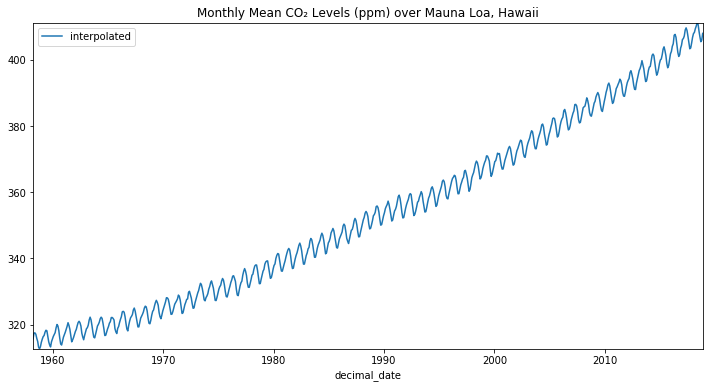

```python
title = 'Monthly Mean CO₂ Levels (ppm) over Mauna Loa, Hawaii'
df.plot('decimal_date','interpolated',figsize=(12,6),title=title).autoscale(axis='both',tight=True);
```

The above plot clearly illustrates some of the fundamentals of time series analysis:

- **trend** - over the past 60 years there is a clear, non-linear upward trend in the levels of CO<sub>2</sub> in the atmosphere at Mauna Loa, Hawaii
- **seasonality** - within any given year there are cyclical patterns of rising and falling CO<sub>2</sub> levels
- **noise** - we also see random, non-systemic fluctuations in the data

## What are "endog" and "exog"?

The data seen in a time series is described as either *endogenous*, that is, caused by factors within the system, or *exogenous*, caused by factors outside the system. We'll see that many statsmodels tools use `endog` to represent the incoming time series data in place of the constant `y`.  
For more information, visit http://www.statsmodels.org/stable/endog_exog.html